# Estimating Foliar Traits from Imaging Spectroscopy Using Spike-and-slab Regression

Coleman Breen

# Summary

We use Spike-and-slab regression (SSR) models to predict 31 foliar traits given hyperspectral imagery data.

1. Spike-and-slab models perform comparatively to baseline Partial Least Squares Regression (PLSR) models in all foliar traits.
2. SSR models provide interpretability because posterior distributions of $\beta$ are given–allowing for estimates of mean and variance.
3. Uncertainty quantification is achieved through two estimated parameters, both of which are baked into SSR models.
- The first parameter estimates the probability that a regressor has no association with the foliar trait of interest (i.e. regression coefficient is zero).
- The second is the variability in the regression coefficients themselves. From these, we can construct credible intervals and conduct hypothesis tests on particular regression coefficients as desired.
4. Further work is needed to incorporate likely spatial dependence and pseudo-replication from pixels.

# Background

Foliar traits refer to chemical, physiological, and morphological properties of leaves which are associated with an underlying biological process. Among the many reasons researchers are interested in these traits are tracking the health of an ecosystem, understanding how it changes over time, and quantifying changes as a result of climate change. Foliar traits are costly to measure as they require experts to travel to a site and record measurements by hand.

Reflectance spectra refer to the light reflected by plant leaves. Unlike what can be observed with the naked eye, hyperspectral sensors are able to capture a large slice of the electromagnetic spectrum at finely spaced intervals. These measurements are taken over large tracts and are used as regressors against various foliar traits.

While this problem could lend itself to a multivariate treatment (i.e. many wavelength covariates mapping to many many foliar traits), we will consider each response separately to aid model interpretability and lessen computational burden.

# Analytical Approach

To provide good model interpretability, induce sparsity, and lay the foundation for (potentially) more complex Bayesian analyses, we assume a Spike-and-slab Regression (SSR) model. We first explain the utility of a SSR model. We then compare the performance to a Partial Least Squares Regression (PLSR) for all foliar traits.

## Data Pre-Processing

As employed in the problem statement, we average all plot pixels. We center all features (i.e. bands) to have zero mean and standard deviation of one.

## Training Scheme

We use 80-20 train-test split to train both models for each foliar trait. To make comparisons as fair as possible, we use the same training set for PLSR and SSR models. We run 20,000 Markov Chain Monte Carlo samples for each foliar trait (see supplement for details).

## Spike-and-slab regression (SSR)

Spike-and-slab regression is Bayesian linear model that is similar in spirit to the widely-used LASSO regression. Like LASSO, it can effectively set coefficients to zero, inducing much-needed sparsity in high-dimensional settings.

The prior distribution for each regression coefficient is a mixture of two components. The first component–called the spike–is a point mass distribution at zero. If a regression coefficient is drawn from the spike it has to be zero. The second component is the slab, so called because it has a relatively flat and dispersed profile. If a sampled regression coefficient is drawn from the slab is can take on a wide range of (non-zero) values.

Letting $N$ be the number of observations, and $p$ the number of band features, we have the following model.

$$\rm{Foliar \; trait} \sim X \beta +
\epsilon$$

where $X \in \mathbb{R}^{N\times p}$. The Spike-and-slab “twist” is assuming that each $\beta \sim \pi \times (\rm{From \; slab}) + (1-\pi) \times (\rm{From \; spike})$, where $\pi$ is a mixing probability. A high value of $\pi$ indicates a coefficient is probably non-zero. Conversely, a low value indicates a coefficient is likely zero.

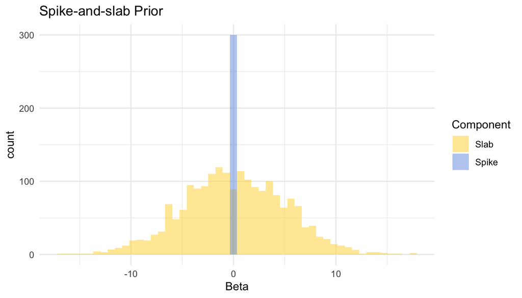

Spike-and-slab priot for a single regression coefficient. The spike (blue) component acts as a regularization term–pushing coefficient towards zero. The second component (slab; yellow) allows the regression coefficient to be almost anything so long as it is not zero.

## PLSR Model

PLSR models are fit using R’s `pls` package. Training samples are cross-validated with `pls`’s default configuration. The number of components kept are determined using Prediction Residual Error Sum of Squares (PRESS) statistic (Chen et. al. 2004) in a similar vain as Wang et. al.

# Results

## Predicted Values for Both Models are Reasonable

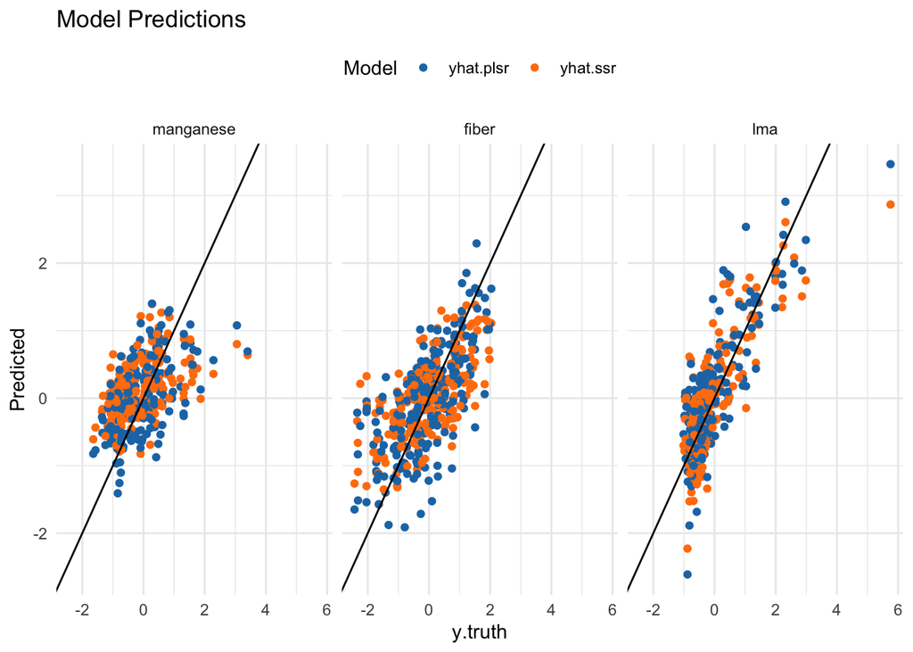

True foliar trait value (x-axis) plotted against predicted (y-axis) for PLSR (blue) and SSR (orange). Black line indicates perfect prediction. Shown are three foliar traits with worst (manganese), median (fiber), and best (lma) average model performance–assesed by taking average R^2 values for PLSR & SSR models.

## Model $R^2$ Values Are Comparable For Both Models

Next, we assess whether SSR models can match PLSR based on out-of-sample prediction accuracy. To measure this, we plot the $R^2$ values computed on the 20% hold-out test set for each foliar trait. As shown below, $R^2$ values are similar for all Foliar traits. While small performance differences warrant further exploration, we cannot make statistically principled statements about SSR or PLSR performing better across the board.

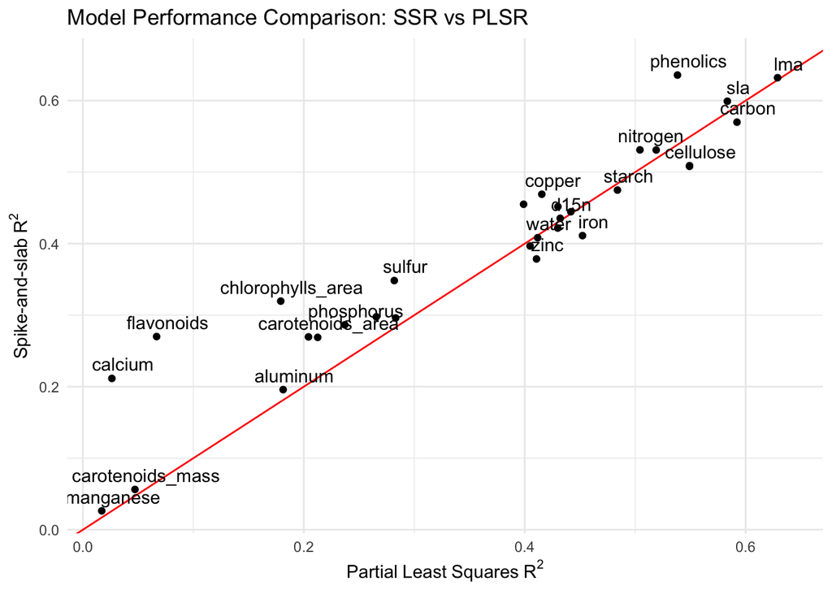

R2 values for PLSR model (x-axis) and SSR (y-axis) for 31 foliar traits. Red line indicates perfect concordance. Models perform similarly well for all traits. However, direct comparisons cannot be made because of varying numbers of model parameters. Note that some foliar trait labels were dropped to aid readability.

## Spike-and-slab Provides An Additional Level of Interpretability

We would expect that “larger” regression coefficients (either positive or negative) as long as their respective variance is sufficiently small. The plot below shows the relationship between the size of $\beta$ estimates alongside the probability of being non-zero. While there are some points with high probability of being non-zero *and* large effect size, there are many points that are high in one but not the other (Fig. 4). This means that the set of regression coefficients that are non-zero do not always have the largest effect sizes (and vice-versa). This lends credence to the use of Spike-and-slab priors, which give estimates of both $\beta$, and $\mathbb{P}[\rm{Non-zero}]$.

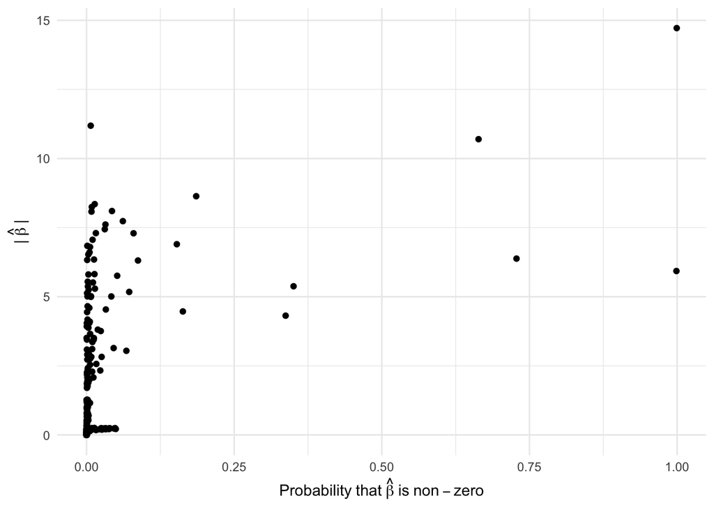

Probability of coming from the Slab distribution (i.e. being non-zero; x-axis) against absolute estimated regression coefficient. Shown are estimates for one foliar trait (zinc).

As an example, we can plot both the estimated $\beta$ coefficients and probabilities of being (non-)zero. Figure 5 summarizes these findings for Zinc. Red bars indicate wavelengths that have a probable association with Zinc. Heights of bars indicate estimated effect. Numerous wavelengths have moderate to large effect sizes but are still more likely to be zero, underscoring the need for sparsity. Just four wavelengths are more likely than not to be included in the model (i.e. non-zero).

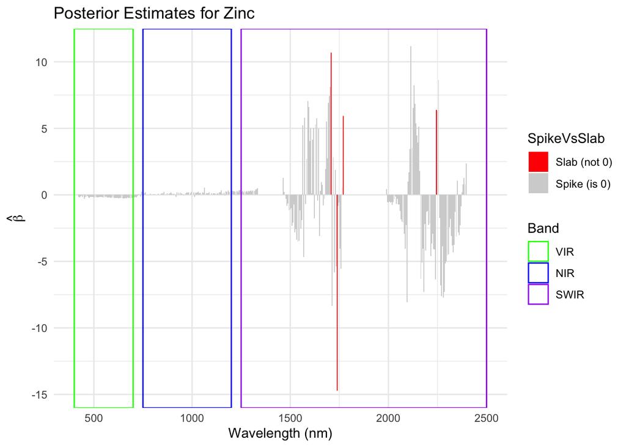

Posterior estimates of regression coefficients over a range of wavelengths. Height of bars indicate estimated effect. Grey bars indicate that a regression coefficient is more likely zero; red inficates it is more likely non-zero. Colored boxes indicated wavelength band.

# Conclusion

## Extensions

Having shown Spike-and-slab regression offers comparable performance to Partial Least Squares Regression, we now briefly consider four extensions.

1. **Using pseudo-replicates in the pixels.** There are multiple methods for better utilizing the pixel replicates; for example, a hierarchical model could be employed.
2. **Incorporating spatial dependence.** We could incorporate the spatial structure (namely that some neighboring bioregions should have similar plant compositions) and allow information-sharing with and Conditional Autoregressive Model (see for example [ICAR example](https://mc-stan.org/users/documentation/case-studies/icar_stan.html)).
3. **Assuming a “Horseshoe” prior.** Like the Spike-and-slab prior, a horseshoe prior induces sparsity. It may be more effective in terms of model performance or feature selection.
4. **Sharing information among foliar traits**. If we have *a priori* information that a pair of foliar traits should have similar reflectance across the spectrum, than we could treat it as a multivariate problem. However, the below plot shows the estimated coefficients from SSR for each foliar trait do not have much of a pattern.

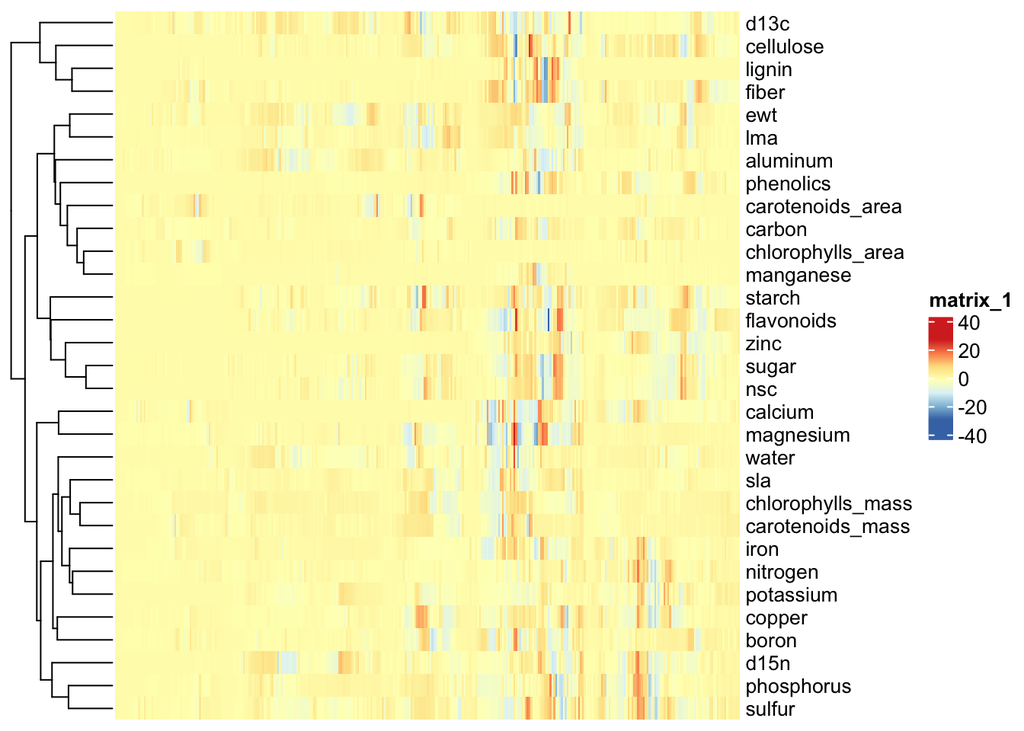

Heatmap of estimated regression coefficeints for all foliar traits (y-axis) across all wavelengths (x-axis). Red indicates positive association with a trait; blue indicates negative association. There is not strong evidence that information sharing among foliar traits would be beneficial.

## Summary

We show that a Spike-and-slab regression model performs comparably to the widely-used Partial Least Squares Regression model. While generating posterior distributions for Spike-and-slab models requires greater up-front computational cost, it also allows for uncertainty quantification and model interpretability. Extensions abound and include leveraging spatial dependence, utilizing pixel-wise values as pseudo-replicates, and experimenting with a bespoke prior distribution.

# References

Liland K, Mevik B, Wehrens R (2022). *pls: Partial Least Squares and Principal Component Regression*. R package version 2.8-1, https://CRAN.R-project.org/package=pls.

Scott SL (2022). *BoomSpikeSlab: MCMC for Spike and Slab Regression*. R package version 1.2.5, https://CRAN.R-project.org/package=BoomSpikeSlab.

# Supplement

## Number of burnin samples

Number of burn-in / warm-up samples used for each foliar trait is reported below. In accordance with best practices in Bayesian modeling, we remove burn-in samples before computing posterior estimates. To pick the number of MCMC samples to drop we use the internal function `SuggestBurninFromLikelihood()` from `BoomSpikeSlab` pacakge. All traits had at least 5,000 usable MCMC samples *except lignin*. Estimates for lignin are less reliable as a result.

| FoliarTrait | BurnInSamples | UsableSamples |
| --- | --- | --- |
| carbon | 27 | 19973 |
| chlorophylls_mass | 31 | 19969 |
| magnesium | 33 | 19967 |
| manganese | 49 | 19951 |
| aluminum | 55 | 19945 |
| nitrogen | 56 | 19944 |
| phenolics | 58 | 19942 |
| carotenoids_mass | 71 | 19929 |
| nsc | 73 | 19927 |
| potassium | 87 | 19913 |
| boron | 90 | 19910 |
| zinc | 101 | 19899 |
| ewt | 117 | 19883 |
| phosphorus | 142 | 19858 |
| carotenoids_area | 164 | 19836 |
| flavonoids | 239 | 19761 |
| sulfur | 272 | 19728 |
| iron | 292 | 19708 |
| d15n | 329 | 19671 |
| cellulose | 338 | 19662 |
| sugar | 352 | 19648 |
| sla | 353 | 19647 |
| starch | 364 | 19636 |
| water | 584 | 19416 |
| chlorophylls_area | 736 | 19264 |
| copper | 759 | 19241 |
| fiber | 837 | 19163 |
| lma | 2479 | 17521 |
| d13c | 7212 | 12788 |
| calcium | 14105 | 5895 |
| lignin | 18098 | 1902 |